# Transportation & Emissions

Ali Sanford

May 1, 2017

# The Relationship Between Public Transportation and Emissions in Two Major CA Cities

Is a neighborhood’s proximity to public transit stops related to its carbon emissions?

-We hypothesized that zip codes with more public transit stops would have less carbon emissions overall

-We thought it would be interesting to see if this relationship was affected by a zip code’s average household income

-We also wondered if the relationship changes when carbon emissions are adjusted for the population of the zip code

# Data Sets and Methods

Emissions Data

-The Cool Climate Network provided us with a dataset including carbon emissions for every zip code in the US, broken down by emission type

-It also included other information about each zip code

-We filtered the data for zip codes within Los Angeles and San Francisco, and selected only the relevant variables, including Longitude and Latitude, Transport Emissions and Average Income Per Household

Transit Stop Data

-Public transit systems make their system data available in GTFS format, which includes .txt files with each stop’s name, longitude and latitude

-We joined together the data for all transit systems in LA and in SF so that we had the coordinates for each stop in each city

Methods

-We cleaned the data using functions such as `mutate()`, `filter()`, `select()`, `join()`, and others that we learned in class

-We calculated distances between zip codes and transit stops and determined the number of stops nearby each zip code using nested for loops with if/else statements inside them

-We also brought in things from outside of class - the geo.sphere package, arcGIS mapping, and ggmapping

# Visualizing the Relationship

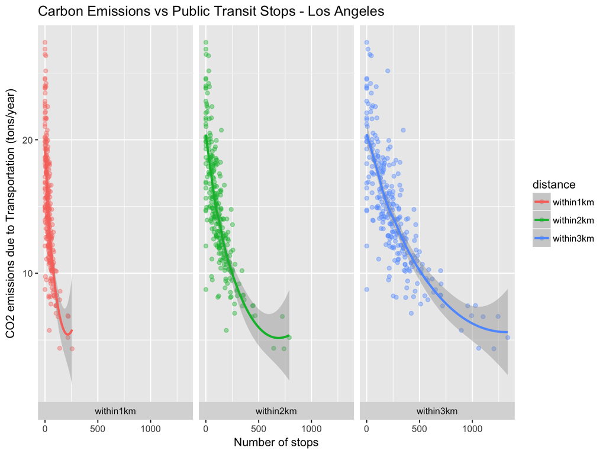

```r
laplotfaceted <- LAnarrowslides %>%
  ggplot(aes(x = number_of_stops, y = Transport.tCO2e.yr., col = distance)) +
  geom_point(alpha = .4) +
  stat_smooth(method = "loess") + facet_grid(. ~ distance, switch = "both") +
  labs(title="Carbon Emissions vs Public Transit Stops - Los Angeles", x="Number of stops", y="CO2 emissions due to Transportation (tons/year)")
laplotfaceted
```

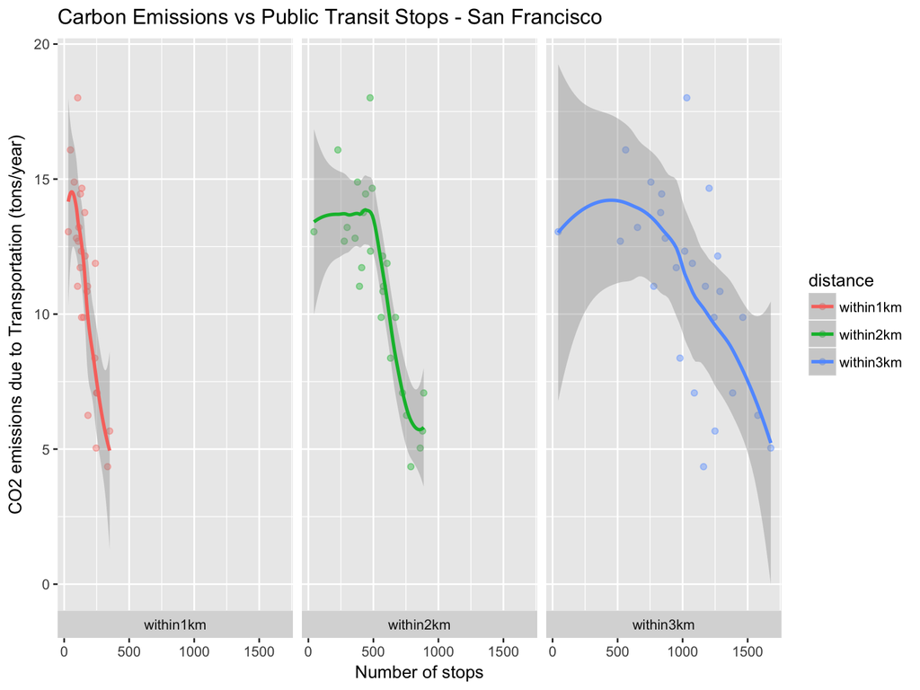

```r
sfplotfaceted <- SFnarrowslides %>%
  ggplot(aes(x = number_of_stops, y = Transport.tCO2e.yr., col = distance)) + geom_point(alpha = .4) + stat_smooth(method = "loess") + facet_grid(. ~ distance, switch = "both") +
  labs(title="Carbon Emissions vs Public Transit Stops - San Francisco", x="Number of stops", y="CO2 emissions due to Transportation (tons/year)")
sfplotfaceted
```

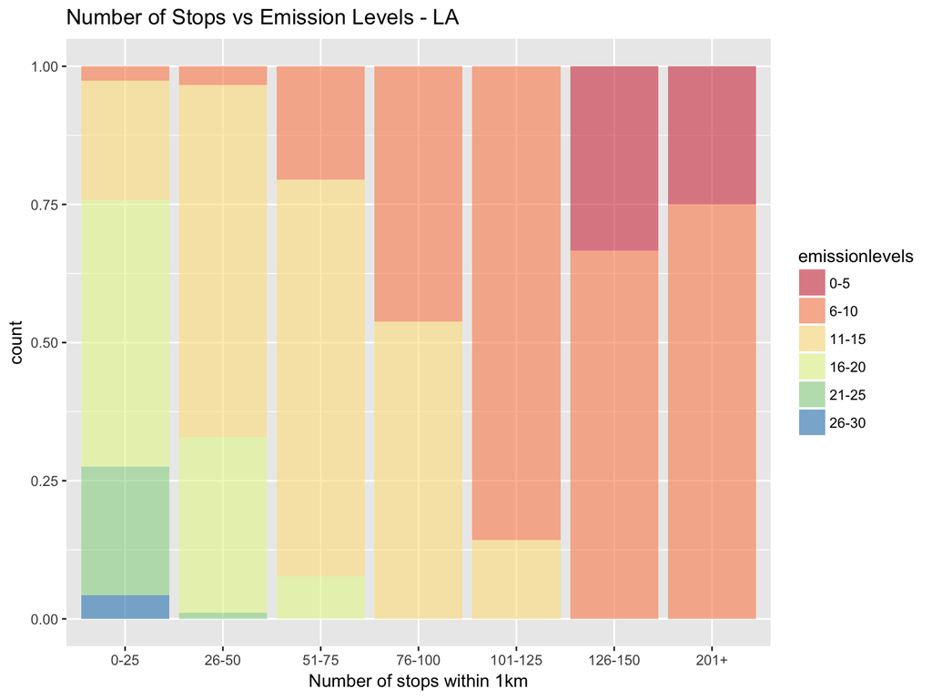

```r
ggplot(emissionsdataLA1slides, aes(x = stoplevels, fill = emissionlevels)) +
  geom_bar(position = "fill", alpha = 0.6) +
  scale_fill_brewer(palette = "Spectral") +
  labs(title="Number of Stops vs Emission Levels - LA", x="Number of stops within 1km", legend = "Carbon Emissions from Transportation (tons/yr)")
```

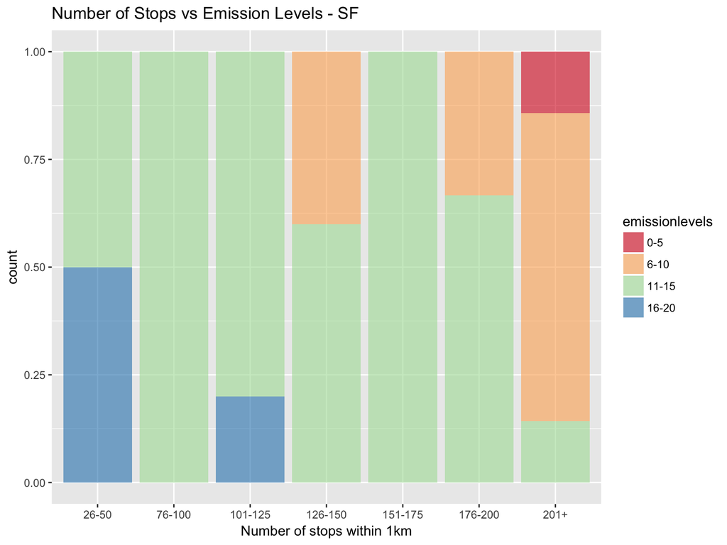

```r
ggplot(emissionsdataSF1slides, aes(x = stoplevels, fill = emissionlevels)) +
  geom_bar(position = "fill", alpha = 0.6) +
  scale_fill_brewer(palette = "Spectral") +
  labs(title="Number of Stops vs Emission Levels - SF", x="Number of stops within 1km", legend = "Carbon Emissions from Transportation (tons/yr)")
```